# The Gender Balance in Mathematical Sciences: A Case Study

Exploratory analysis of gender proportion in School of Mathematics and Statistics at The University of Sydney.

Emi Tanaka https://github.com/emitanaka (School of Mathematics and Statistics, The University of Sydney)  
01-20-2019

### Table of Contents

Diversity and inclusion plays an important role in science and also for the wider community. [An extensive analysis of 600 decisions by 200 business teams by Forbes](https://www.forbes.com/sites/eriklarson/2017/09/21/new-research-diversity-inclusion-better-decision-making-at-work/#454e61c64cbf) suggests that a more diverse and inclusive team makes better decisions. Presumably this is because the team would take into account different perspectives.

There are many different types of diversity (ethnic background, age, gender, training background etc) but today the topic at hand is *gender diversity*. There are now rising movements now to support the minority gender such as the [R-Ladies](https://rladies.org/), [Forwards](https://forwards.github.io/) and [MAGIC Workshops](http://wp.maths.usyd.edu.au/MAGIC/). Some institutions have advertised for female only positions as a way to tackle gender diversity in male-dominated faculties. These movements were at times met with criticisms. Some also believe that certain gender are inherently prone to entering (or not entering) certain fields and devalue any active intervention.

With historical bias where female were often removed from further study and held to certain expectations and minority gender were often suppressed, it is hard to tell what the natural equilibrium for the gender proportion should be in many fields. Many would agree though that the female or non-binary representation for students and staff in the mathematical and statistical discipline are low. The aim of this article is to examine *how low* this is by examining the data from School of Mathematics and Statistics, The University of Sydney.

## Data

The data for the number of honours and HDR graduates in the School of Mathematics and Statistics at The University of Sydney are sourced from [here](http://www.maths.usyd.edu.au/u/SMS/HonoursMF.html) and [here](http://www.maths.usyd.edu.au/u/SMS/HdrMF.html), respectively.

The number of current staff and students are complied from the public list [here](http://www.maths.usyd.edu.au/ut/people.html) with removal of certain personnel that are no longer at the School or do not occupy an office within the Carslaw building (with one exception) and gender identification from my personal knowledge as a member of staff. I have tried to the best of my knowledge infer the research group and appointment level but there is likely some mistake. Any mistake in the collection of this data are of my own.

Note: gender is prescribed here as what binary gender (male or female) the person likely identify with or inferred from their names or faces if I don’t personally have the information at hand.

## Exploratory Analysis

Below are a series of barplot for the number of student graduates and staff by gender[^1].

### Honours Student Graduates

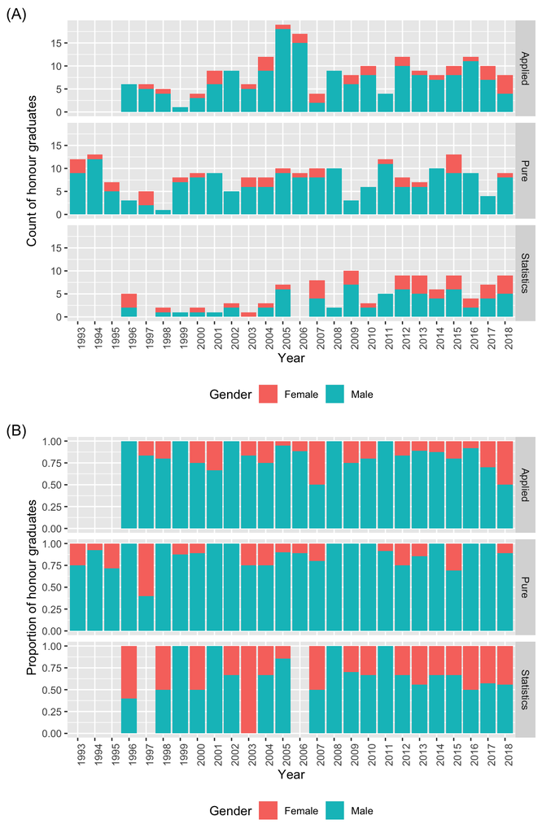

Figure 1: Above graphs show the count (A) and proportions (B) of honour student graduates from School of Mathematics and Statistics at The University of Sydney by the three major research groups.

### Higher Degree Research (HDR) Student Graduates

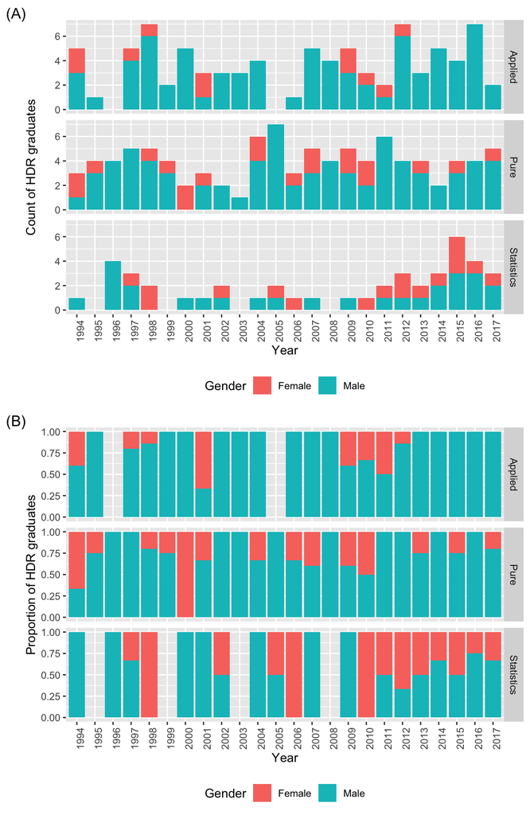

Figure 2: Above graphs show the count (A) and proportions (B) of HDR student graduates from School of Mathematics and Statistics at The University of Sydney by the three major research groups.

### Current HDR Students and Staff

There are currently 83 HDR students and 86 faculty staffs. The division of these by the three major research groups are shown below.

| **Status** | Group Applied | Group Pure | Group Statistics | Total |
| --- | --- | --- | --- | --- |
| **Staff** | 23 | 45 | 18 | 86 |
| **Student** | 37 | 20 | 26 | 83 |
| **Total** | 60 | 65 | 44 | 169 |

Generated by summarytools 0.8.8 ([R](https://www.r-project.org/) version 3.5.1)  
2019-03-07

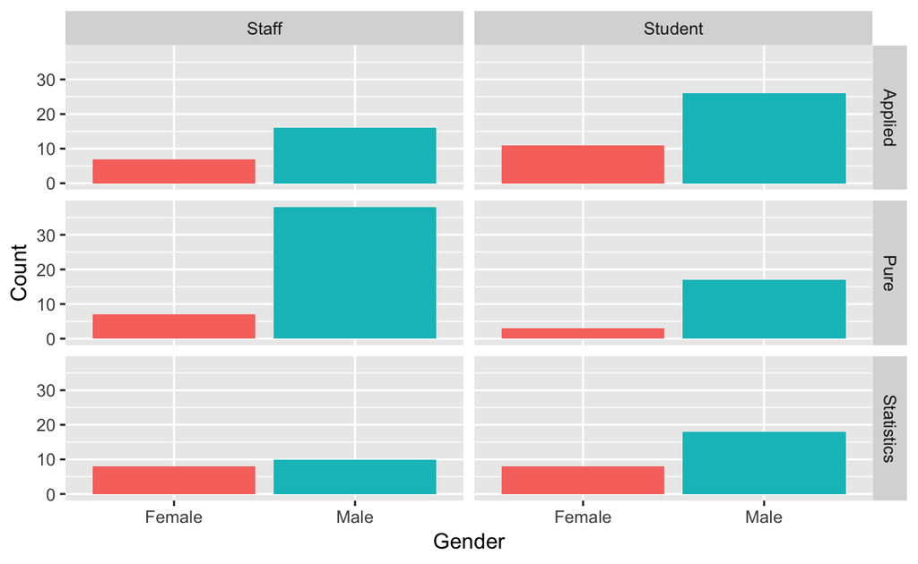

Figure 3: This barplot shows the number of staff or current HDR student for each gender by the three major research groups.

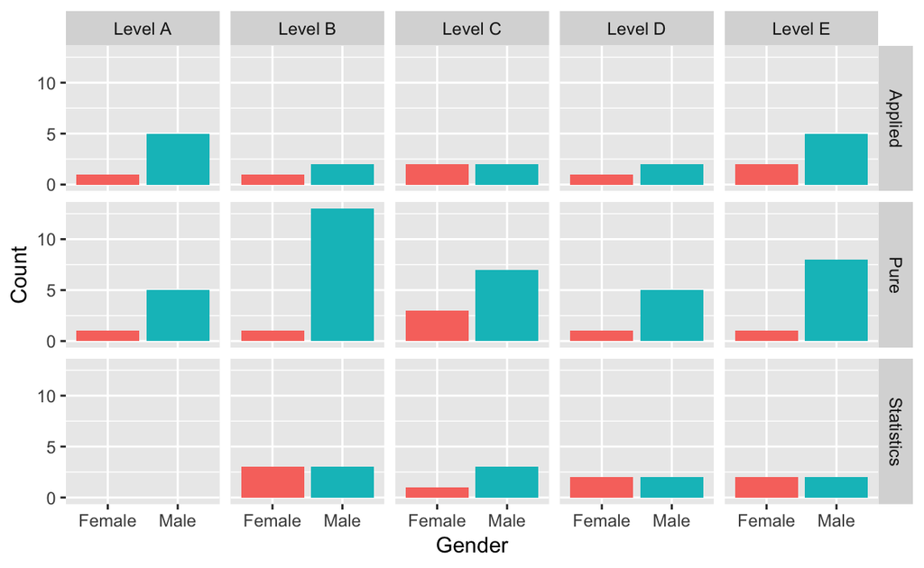

Figure 4: This barplot shows the number of staff in each gender by their appointment level. Note B=Lecturer or Assistant Professor in the US system; C=Senior Lecturer; D=Associate Professor and E=Professor.

### Closer look: Statistics Research Group

As I am a statistician within the School, naturally I know more about the members of the [Statistics Research Group](http://www.maths.usyd.edu.au/ut/printgrouplist.py?group=Statistics) (including about certain promotions that took place that is yet to be updated on the website). So I am better able clean this data.

Some [listed](http://www.maths.usyd.edu.au/ut/printgrouplist.py?group=Statistics) technically do not constitute as full-time staff within the School so I removed those that are in the list that are PhD students or those who do not have an office within the Carslaw building with an exception of one Professor (who technical should have an office in Carslaw).

In total there are 18 full-time staff members of which 2 are on fixed-term Level B contracts (one of each gender). Below cross-tabulation shows the number of staff members by level (B=Lecturer or Assistant Professor in the US system; C=Senior Lecturer; D=Associate Professor and E=Professor).

[output not shown]

Generated by summarytools 0.8.8 ([R](https://www.r-project.org/) version 3.5.1)  
2019-03-07

## Some Commentary

If gender diversity is important for making better decisions then there certainly is a need to encourage more the minority gender to pursue higher levels of mathematics and statistics.

## Acknowledgments

This article is written using `radix`<sup>(Allaire, Iannone, and Xie 2018)</sup> using [RStudio IDE](https://www.rstudio.com/) and statistical computing tool [R](https://www.r-project.org/)(*R: A Language and Environment for Statistical Computing* 2018). The graph was made using `ggplot2`<sup>(Wickham 2016)</sup> and `patchwork`<sup>(Pedersen 2017)</sup>. The cross-tabulation was made by `summarytools` <sup>(Comtois 2018)</sup>.

## Reuse

Text and figures are licensed under [Creative Commons Attribution CC BY 4.0](https://creativecommons.org/licenses/by/4.0/). Source code is available at https://github.com/emitanaka/r/_posts.

## Corrections

If you see mistakes or want to suggest changes, please create an [issue on the source repository](https://github.com/emitanaka/r/issues).

Allaire, JJ, Rich Iannone, and Yihui Xie. 2018. *Radix: ’R Markdown’ Format for Scientific and Technical Writing*. https://github.com/rstudio/radix.

Comtois, Dominic. 2018. *Summarytools: Tools to Quickly and Neatly Summarize Data*. https://CRAN.R-project.org/package=summarytools.

Pedersen, Thomas Lin. 2017. *Patchwork: The Composer of Ggplots*. https://github.com/thomasp85/patchwork.

*R: A Language and Environment for Statistical Computing*. 2018. Vienna, Austria: R Foundation for Statistical Computing. https://www.R-project.org/.

Wickham, Hadley. 2016. *Ggplot2: Elegant Graphics for Data Analysis*. Springer-Verlag New York. http://ggplot2.org.

[^1]: This data is excellent for illustrating the use of `geom_bar` in `ggplot2`!